# AD2 2016.2 - Lab3 - Parte 3

Marianne Linhares

12 de março de 2017

# Bibliotecas Utlizadas

Primeiramente vamos importar as bibliotecas necessárias para esse script ser executado.

```r
library(dplyr)
library(reshape2)
library(GGally)
library(ggplot2)
library(corrplot)
library(caret)
library(rpart)
library(C50)
library(gmodels)
library(randomForest)
```

# Descrição da atividade

Aqui se encontram as técnicas e modelos adotados para realização das submissões do [desafio no Kaggle](https://inclass.kaggle.com/c/previsao-de-evasao-em-computacao).

# 0. Antes de melhorar os modelos…

## 0.1 Funções auxiliares e variáveis globais

Para preparar e transformar os dados foram usadas as funções e variáveis auxiliares apresentadas nesta seção.

```r
COL_DADOS = c("matricula", "cod_disciplina", "disciplina", "ano", "periodo", "media", "evadiu")

COL_DADOS_KAGGLE = c("matricula", "cod_disciplina", "disciplina", "ano", "periodo", "media")

COL_T = c("matricula", "AV", "C1", "IC", "LP1", "LPT", "P1", "evadiu", "ano", "periodo")

COL_T_KAGGLE = c("matricula", "AV", "C1", "IC", "LP1", "LPT", "P1")

NOTA_REP = 5
NOTA_FINAL = 7

INICIO_DISC = 2
FIM_DISC = 7
NUM_DISC = 6

select_treino <- function(ano_periodo) {
  return(as.integer(ano_periodo) >= 20091  & as.integer(ano_periodo) <= 20142)
}

calcula_status <- function(C1, AV, IC, LP1, LPT, P1) {
  return (
    (C1 < NOTA_REP) & (AV < NOTA_REP) & (IC < NOTA_REP) & (LP1 < NOTA_REP) &
    (LPT < NOTA_REP) & (P1 < NOTA_REP)
  )
}

calcula_cra <- function(C1, AV, IC, LP1, LPT, P1) {
  return((C1 + AV + IC + LP1 + LPT + P1)/NUM_DISC)
}

calcula_cra_cc <- function(IC, LP1, P1) {
  return((IC + LP1 + P1)/3)
}

calcula_num_finais <- function(C1, AV, IC, LP1, LPT, P1) {
  return(
    (C1 < NOTA_FINAL) + (AV < NOTA_FINAL) + (IC < NOTA_FINAL) + (LP1 < NOTA_FINAL) +
    (LPT < NOTA_FINAL) + (P1 < NOTA_FINAL)
  )
}

calcula_num_NA <- function(C1, AV, IC, LP1, LPT, P1) {
  return(
    NUM_DISC - (is.finite(C1) + is.finite(AV) + is.finite(IC) + is.finite(LP1) +
    is.finite(LPT) + is.finite(P1))
  )
}

decide_na <- function(col, num, media) {
  return(ifelse(is.na(col), ifelse(num > 3, 0, media), col))
}
```

## 0.2 Separando os dados de treino e teste

Para fazer a separação iremos considerar os dados de [2009.1, 2014.2] como treino e [2015.1, 2015.2] como teste. Os demais anos foram retirados, pois vários não apresentaram evasões (isso foi verificado na parte 1) e portanto retirá-los pode diminuir um pouco o desbalanceamento dos dados.

```r
# recebe dados
dados <- read.csv('~/DataAnalysis2/lab3/treino.csv')
dados <- na.omit(dados)

# renomeia colunas
colnames(dados) <- COL_DADOS

# cria coluna para auxiliar separação dos dados
dados$ano_periodo <- paste(as.character(dados$ano), as.character(dados$periodo), sep="")

# separação dos dados
dados <- dados %>% mutate(treino=select_treino(ano_periodo))
aux_split <- split(dados, dados$treino)

teste <- aux_split[[1]]
teste <- teste[teste$ano == 2015,] # apenas o ano de 2015 eh considerado

treino <- aux_split[[2]]
```

```r
# Treino
alunos.evadiu <- treino %>%
  group_by(matricula) %>% select(matricula, evadiu, ano, periodo) %>% unique()

treino <- treino %>%
  group_by(matricula, disciplina) %>%
  ungroup() %>%
  select(matricula, disciplina, media) %>%
  mutate(disciplina = as.factor(gsub(" ", ".", disciplina))) %>%
  dcast(matricula ~ disciplina, mean) %>% merge(alunos.evadiu)
colnames(treino) <- COL_T

# Teste

alunos.evadiu <- teste %>%
  group_by(matricula) %>% select(matricula, evadiu, ano, periodo) %>% unique()

teste <- teste %>%
  group_by(matricula, disciplina) %>%
  ungroup() %>%
  select(matricula, disciplina, media) %>%
  mutate(disciplina = as.factor(gsub(" ", ".", disciplina))) %>%
  dcast(matricula ~ disciplina, mean) %>% merge(alunos.evadiu)
colnames(teste) <- COL_T

# Teste kaggle

teste_k <- read.csv('~/DataAnalysis2/lab3/teste.csv')
# renomeia colunas
colnames(teste_k) <- COL_DADOS_KAGGLE

teste_k <- teste_k %>%
  group_by(matricula, disciplina) %>%
  ungroup() %>%
  select(matricula, disciplina, media) %>%
  mutate(disciplina = as.factor(gsub(" ", ".", disciplina))) %>%
  dcast(matricula ~ disciplina, mean)
colnames(teste_k) <- COL_T_KAGGLE
```

## 0.3 Tratando NAs

```r
# Treino
treino$num_NA <-
  calcula_num_NA(treino$C1, treino$AV, treino$IC, treino$LP1, treino$LPT, treino$P1)

treino$media_NA <-
  rowMeans(subset(treino, select = c(C1, AV, IC, LP1, LPT, P1)), na.rm = TRUE)

for (i in INICIO_DISC:FIM_DISC) {
  treino[, i] <- decide_na(treino[, i], treino$num_NA, treino$media_NA)
}

treino <- subset(treino, select = -c(media_NA, ano, periodo))

# Teste
teste$num_NA <- calcula_num_NA(teste$C1, teste$AV, teste$IC, teste$LP1, teste$LPT, teste$P1)

teste$media_NA <- rowMeans(subset(teste, select = c(C1, AV, IC, LP1, LPT, P1)), na.rm = TRUE)

for (i in INICIO_DISC:FIM_DISC) {
  teste[, i] <- decide_na(teste[, i], teste$num_NA, teste$media_NA)
}

teste <- subset(teste, select = -c(media_NA, ano, periodo))

# Teste Kaggle
teste_k$num_NA <- calcula_num_NA(teste_k$C1, teste_k$AV, teste_k$IC, teste_k$LP1, teste_k$LPT, teste_k$P1)

teste_k$media_NA <- rowMeans(subset(teste_k, select = c(C1, AV, IC, LP1, LPT, P1)), na.rm = TRUE)

for (i in INICIO_DISC:FIM_DISC) {
  teste_k[, i] <- decide_na(teste_k[, i], teste_k$num_NA, teste_k$media_NA)
}

teste_k <- subset(teste_k, select = -c(media_NA))

# Treino
treino$status <-
  calcula_status(treino$C1, treino$AV, treino$IC, treino$LP1, treino$LPT, treino$P1)

treino$cra <-
  calcula_cra(treino$C1, treino$AV, treino$IC, treino$LP1, treino$LPT, treino$P1)

treino$cra_cc <-
  calcula_cra_cc(treino$IC, treino$LP1, treino$P1)

treino$num_finais <-
  calcula_num_finais(treino$C1, treino$AV, treino$IC, treino$LP1, treino$LPT, treino$P1)

# Teste
teste$status <-
  calcula_status(teste$C1, teste$AV, teste$IC, teste$LP1, teste$LPT, teste$P1)

teste$cra <-
  calcula_cra(teste$C1, teste$AV, teste$IC, teste$LP1, teste$LPT, teste$P1)

teste$cra_cc <-
  calcula_cra_cc(teste$IC, teste$LP1, teste$P1)

teste$num_finais <-
  calcula_num_finais(teste$C1, teste$AV, teste$IC, teste$LP1, teste$LPT, teste$P1)

# Teste Kaggle
teste_k$status <-
  calcula_status(teste_k$C1, teste_k$AV, teste_k$IC, teste_k$LP1, teste_k$LPT, teste_k$P1)

teste_k$cra <-
  calcula_cra(teste_k$C1, teste_k$AV, teste_k$IC, teste_k$LP1, teste_k$LPT, teste_k$P1)

teste_k$cra_cc <-
  calcula_cra_cc(teste_k$IC, teste_k$LP1, teste_k$P1)

teste_k$num_finais <-
  calcula_num_finais(teste_k$C1, teste_k$AV, teste_k$IC, teste_k$LP1, teste_k$LPT, teste_k$P1)
```

# 1. Modelo 1

O primeiro modelo enviado foi o modelo que apresentou melhor recall na parte 2 desta atividade, que foi o modelo gerado utilizando rpart (árvore de decisão) e tanto atributos gerais quanto as notas em CC. Segue abaixo a lista de atributos:

- matricula: identificador do aluno
- AV: média em Álgebra Vetorial
- C1: média em Cálculo 1
- IC: média em Introdução a Computação
- LPT: média em Leitura e Produção de Texto
- P1: média em Programação 1
- evadiu: variável de classificação
- num_NA: número de NAs
- status: TRUE se reprovou todas as disciplinas
- cra: média das disciplinas
- cra_cc: média nas disciplinas de cc
- num_finais: número de finais feitas

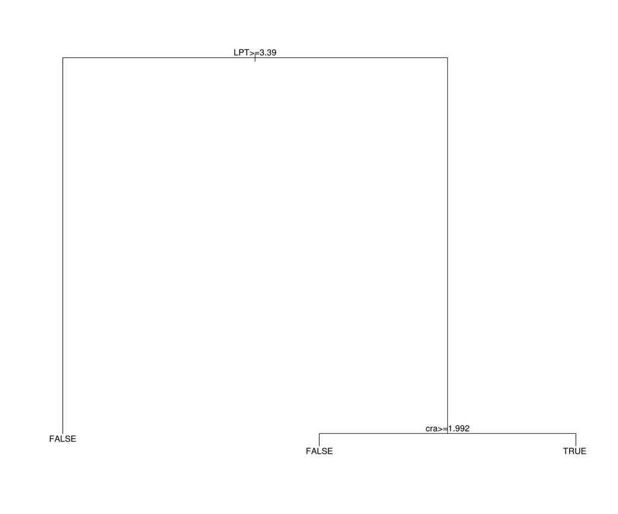

```r
model1 <- rpart(evadiu ~ AV + C1 + LPT + P1 + IC + cra + cra_cc + num_NA + status + num_finais, data = treino, method = 'class')

plot(model1)
text(model1, pretty=0)
```

```r
pred1 <- predict(model1, teste, type='class')

acc1 <- confusionMatrix(pred1, teste$evadiu)
acc1
```

```
## Confusion Matrix and Statistics
##
##           Reference
## Prediction FALSE TRUE
##      FALSE   170    4
##      TRUE      2   13
##
##                Accuracy : 0.9683
##                  95% CI : (0.9322, 0.9883)
##     No Information Rate : 0.9101
##     P-Value [Acc > NIR] : 0.001442
##
##                   Kappa : 0.7952
##  Mcnemar's Test P-Value : 0.683091
##
##             Sensitivity : 0.9884
##             Specificity : 0.7647
##          Pos Pred Value : 0.9770
##          Neg Pred Value : 0.8667
##              Prevalence : 0.9101
##          Detection Rate : 0.8995
##    Detection Prevalence : 0.9206
##       Balanced Accuracy : 0.8765
##
##        'Positive' Class : FALSE
##
```

```r
acc1$byClass['Recall']
```

```
##    Recall
## 0.9883721
```

## 1.1 Previsão nos dados de teste do Kaggle

```r
pred1 <- predict(model1, teste_k, type='class')
sol1 <- data.frame(MAT_ALU_MATRICULA = teste_k$matricula, EVADIU=(pred1 == TRUE))

write.csv(sol1, file = 'sol1.csv', row.names = F)
```

Esse modelo obteve score de 0.84314 que pode ser considerado um bom resultado.

# 2. Modelo 2: Regressão Logística + CSL

Inicialmente minha ideia era balancear os dados, mas depois de ler alguns blogs e posts decidi utilizar a técnica de Cost Sensitive Learning (CSL) em vez de balancear os dados.

De forma simples CSL busca lidar com o desbalanceamento atribuindo diferentes pesos pra diferentes problemas de “misclassification”. Não criamos novos dados, nem retiramos dados, apenas associamos pesos que irão enfatizar o custo da classificação feita erroneamente para casos particulares.

Não encontrei nenhum método específico para CSL no R, então uma abordagem similar é utilizar outra métrica para avaliar e gerar o modelo, assim a métrica utilizada foi Kappa (mais detalhes em [6]) que é tida como uma melhor métrica que a acurácia para dados desbalanceados.

Mais detalhes sobre as decisões tomadas podem ser vistas em [1], [2], [3]. Além disso mais detalhes sobre CSL podem ser vistos em [3].

```r
ctrl <- trainControl(method = "repeatedcv", number = 10, savePredictions = TRUE)

model2 <- train(as.factor(evadiu) ~ AV + C1 + LPT + P1 + IC + cra + cra_cc + num_NA + status + num_finais,
                   data=treino,
                   method="glm",
                   family="binomial",
                   na.action=na.omit,
                   metric="Kappa",
                   trControl=ctrl)
model2
```

```
## Generalized Linear Model
##
## 630 samples
##  10 predictors
##   2 classes: 'FALSE', 'TRUE'
##
## No pre-processing
## Resampling: Cross-Validated (10 fold, repeated 1 times)
## Summary of sample sizes: 567, 567, 567, 567, 567, 567, ...
## Resampling results:
##
##   Accuracy  Kappa
##   0.952381  0.6902031
##
##
```

```r
pred2 <- predict(model2, teste, type='prob')
acc2 <- confusionMatrix(pred2[, 2] > 0.7, teste$evadiu)
acc2
```

```
## Confusion Matrix and Statistics
##
##           Reference
## Prediction FALSE TRUE
##      FALSE   170    4
##      TRUE      2   13
##
##                Accuracy : 0.9683
##                  95% CI : (0.9322, 0.9883)
##     No Information Rate : 0.9101
##     P-Value [Acc > NIR] : 0.001442
##
##                   Kappa : 0.7952
##  Mcnemar's Test P-Value : 0.683091
##
##             Sensitivity : 0.9884
##             Specificity : 0.7647
##          Pos Pred Value : 0.9770
##          Neg Pred Value : 0.8667
##              Prevalence : 0.9101
##          Detection Rate : 0.8995
##    Detection Prevalence : 0.9206
##       Balanced Accuracy : 0.8765
##
##        'Positive' Class : FALSE
##
```

```r
acc2$byClass['Recall']
```

```
##    Recall
## 0.9883721
```

## 2.1 Previsão nos dados de teste do Kaggle

```r
pred2 <- predict(model2, teste_k, type='prob')
pred2 <- pred2[, 2] > 0.7
sol2 <- data.frame(MAT_ALU_MATRICULA = teste_k$matricula, EVADIU=(pred2 == TRUE))

write.csv(sol2, file = 'sol2.csv', row.names = F)
```

Não houve melhoria nos testes do Kaggle, apesar de: sol1.csv != sol2.csv.

Esse modelo obteve score de 0.84314.

# 3. Modelo 3: Random forest

Para tentar melhorar os resultados, decidi utilizar Random forest que é um método bastante utilizado e popular em desafios e na literatura.

Random forest irá criar vários modelos diferentes, porém simples, e unir os resultados para criar uma boa árvore de decisão, mais sobre Random forest pode ser visto em [4] e [5].

O modelo abaixo utiliza os mesmos atributos dos modelos anteriores e 2000 “sub-árvores” serão geradas.

```r
model3 <- randomForest(evadiu ~ AV + C1 + LPT + P1 + IC + cra + cra_cc + num_NA + status +
                      num_finais,
                      data=treino,
                      importance=TRUE,
                      ntree=2000)
model3
```

```
##
## Call:
##  randomForest(formula = evadiu ~ AV + C1 + LPT + P1 + IC + cra +      cra_cc + num_NA + status + num_finais, data = treino, importance = TRUE,      ntree = 2000)
##                Type of random forest: regression
##                      Number of trees: 2000
## No. of variables tried at each split: 3
##
##           Mean of squared residuals: 0.0450216
##                     % Var explained: 47.75
```

```r
pred.3 <- predict(model3, teste, type='class')

acc.3 <- confusionMatrix(pred.3 > 0.7, teste$evadiu)
acc.3
```

```
## Confusion Matrix and Statistics
##
##           Reference
## Prediction FALSE TRUE
##      FALSE   170    4
##      TRUE      2   13
##
##                Accuracy : 0.9683
##                  95% CI : (0.9322, 0.9883)
##     No Information Rate : 0.9101
##     P-Value [Acc > NIR] : 0.001442
##
##                   Kappa : 0.7952
##  Mcnemar's Test P-Value : 0.683091
##
##             Sensitivity : 0.9884
##             Specificity : 0.7647
##          Pos Pred Value : 0.9770
##          Neg Pred Value : 0.8667
##              Prevalence : 0.9101
##          Detection Rate : 0.8995
##    Detection Prevalence : 0.9206
##       Balanced Accuracy : 0.8765
##
##        'Positive' Class : FALSE
##
```

```r
acc.3$byClass['Recall']
```

```
##    Recall
## 0.9883721
```

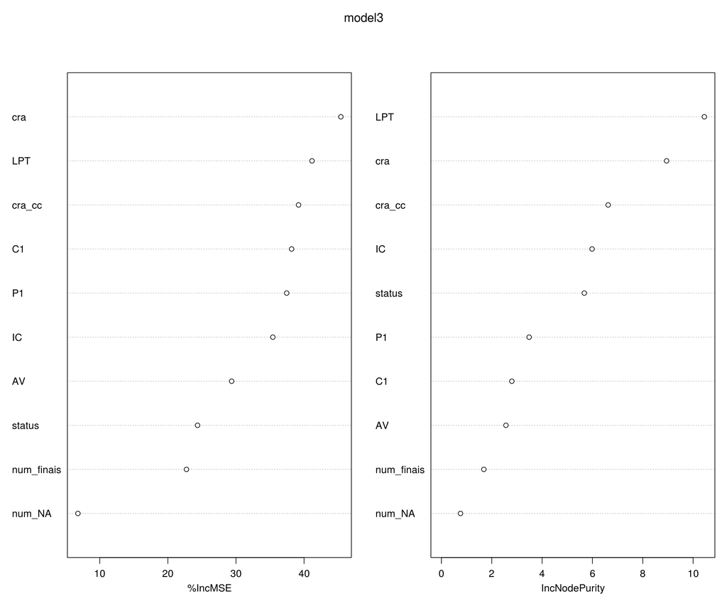

```r
varImpPlot(model3)
```

Sobre o gráfico acima, são dois gráficos que medem a importância das variáveis. O mais a esquerda mostra o quão pior é o modelo sem essa variável então as variáveis com maiores valores são “mais importantes”. Já o gráfico a direita utiliza detalhes da matemática utilizada pelo Random Forest, mas basicamente mede o quão simples os nós são no fim da árvore.

## 2.1 Previsão nos dados de teste do Kaggle

```r
pred3 <- predict(model3, teste_k, type='class')
sol3 <- data.frame(MAT_ALU_MATRICULA = teste_k$matricula, EVADIU=(pred3 > 0.7))

write.csv(sol3, file = 'sol3.csv', row.names = F)
```

Esse modelo obteve score de 0.84314, como esperado.

# Referências

[1. Desbalanceamento 1](http://www.win-vector.com/blog/2015/02/does-balancing-classes-improve-classifier-performance/)

[2. Desbalanceamento 2](https://www.r-bloggers.com/unbalanced-data-is-a-problem-no-balanced-data-is-worse/)

[3. Desbalanceamento 3](https://www.analyticsvidhya.com/blog/2016/03/practical-guide-deal-imbalanced-classification-problems/)

[4. random forest](https://en.wikipedia.org/wiki/Random_forest)

[5. random forest in R](https://cran.r-project.org/web/packages/randomForest/randomForest.pdf)

[6. Kappa](https://en.wikipedia.org/wiki/Cohen's_kappa)